# Modelado de Churn para una Empresa de Telecomunicaciones

Author

Ing Gabriel Chávez Camargo

Published

October 14, 2024

[figure not shown]

# **PROBLEMA DE NEGOCIO**

Una empresa de telecomunicaciones desea mejorar la retención de sus clientes, identificando aquellos que tienen más chances de abandonar el servicio (Churn). Como científico de datos, tu objetivo será limpiar y preparar un conjunto de datos para el entrenamiento de un modelo de Churn. A continuación, se presentan las preguntas clave que guiarán el proceso de limpieza de datos:

1. ¿Qué insights podemos obtener del análisis exploratorio inicial del conjunto de datos?
2. ¿Qué transformaciones básicas son necesarias para preparar los datos?
3. ¿Cómo podemos identificar y tratar los datos duplicados y los valores nulos?
4. ¿Cómo manejamos los outliers presentes en el dataset?
5. ¿Qué técnicas aplicamos para procesar las variables categóricas?

# 1. Configuración del ambiente

```python
import time
import numpy as np
import pandas as pd
pd.set_option('display.max_columns', None)
import seaborn as sns
import matplotlib.pyplot as plt
import json
from sklearn.model_selection import train_test_split
from sklearn.ensemble import RandomForestClassifier
from sklearn.feature_selection import SelectKBest
from sklearn.feature_selection import chi2
from sklearn.feature_selection import RFECV
from sklearn.feature_selection import RFE
from sklearn.decomposition import PCA
from sklearn.model_selection import cross_val_score
from sklearn.preprocessing import OrdinalEncoder, MinMaxScaler
from imblearn.over_sampling import RandomOverSampler
global datos_churn
```

# 2. Obtención y Tratamiento de Datos

##2.1 Cargando las Bases de datos

```python
datos_churn = pd.read_json("base_clientes.json")
datos_churn.head()
```

|  | id_cliente | Churn | cliente | telefono | internet | cuenta |
| --- | --- | --- | --- | --- | --- | --- |
| 0 | 0002-ORFBO | no | {'genero': 'femenino', 'anciano': 0, 'pareja':... | {'servicio_telefono': 'si', 'varias_lineas': '... | {'servicio_internet': 'DSL', 'seguridad_online... | {'contrato': None, 'facturacion_electronica': ... |
| 1 | 0003-MKNFE | no | {'genero': 'masculino', 'anciano': 0, 'pareja'... | {'servicio_telefono': 'si', 'varias_lineas': '... | {'servicio_internet': 'DSL', 'seguridad_online... | {'contrato': 'mensual', 'facturacion_electroni... |
| 2 | 0004-TLHLJ | si | {'genero': 'masculino', 'anciano': 0, 'pareja'... | {'servicio_telefono': 'si', 'varias_lineas': '... | {'servicio_internet': 'fibra optica', 'segurid... | {'contrato': 'mensual', 'facturacion_electroni... |
| 3 | 0011-IGKFF | si | {'genero': 'masculino', 'anciano': 1, 'pareja'... | {'servicio_telefono': 'si', 'varias_lineas': '... | {'servicio_internet': 'fibra optica', 'segurid... | {'contrato': 'mensual', 'facturacion_electroni... |
| 4 | 0013-EXCHZ | si | {'genero': 'femenino', 'anciano': 1, 'pareja':... | {'servicio_telefono': 'si', 'varias_lineas': '... | {'servicio_internet': 'fibra optica', 'segurid... | {'contrato': 'mensual', 'facturacion_electroni... |

Cargamos los datos que se encuentran en formato JSON

```python
datos_churn.info()
```

```
<class 'pandas.core.frame.DataFrame'>
RangeIndex: 7344 entries, 0 to 7343
Data columns (total 6 columns):
 #   Column      Non-Null Count  Dtype
---  ------      --------------  -----
 0   id_cliente  7344 non-null   object
 1   Churn       7344 non-null   object
 2   cliente     7344 non-null   object
 3   telefono    7344 non-null   object
 4   internet    7344 non-null   object
 5   cuenta      7344 non-null   object
dtypes: object(6)
memory usage: 344.4+ KB
```

Observamos que tenemos 7344 valores totales, pero adentro encontramos las diferentes columnas.

```python
# Conversion de datos df
def lectura_datos(data):

  with open ('base_clientes.json',encoding='utf-8') as f:
    json_bruto=json.load(f)
    datos_churn=pd.json_normalize(json_bruto)
    return datos_churn


datos_churn=lectura_datos(datos_churn)
```

```python
datos_churn.head()
```

|  | id_cliente | Churn | cliente.genero | cliente.anciano | cliente.pareja | cliente.dependientes | cliente.tiempo_servicio | telefono.servicio_telefono | telefono.varias_lineas | internet.servicio_internet | internet.seguridad_online | internet.backup_online | internet.proteccion_dispositivo | internet.soporte_tecnico | internet.tv_streaming | internet.peliculas_streaming | cuenta.contrato | cuenta.facturacion_electronica | cuenta.metodo_pago | cuenta.cobros.mensual | cuenta.cobros.Total |
| --- | --- | --- | --- | --- | --- | --- | --- | --- | --- | --- | --- | --- | --- | --- | --- | --- | --- | --- | --- | --- | --- |
| 0 | 0002-ORFBO | no | femenino | 0 | si | si | 9.0 | si | no | DSL | no | si | no | si | si | no | None | None | None | NaN | None |
| 1 | 0003-MKNFE | no | masculino | 0 | no | no | 9.0 | si | si | DSL | no | no | no | no | no | si | mensual | no | cheque | 59.9 | 542.4 |
| 2 | 0004-TLHLJ | si | masculino | 0 | no | no | 4.0 | si | no | fibra optica | no | no | si | no | no | no | mensual | si | cheque electronico | 73.9 | 280.85 |
| 3 | 0011-IGKFF | si | masculino | 1 | si | no | 13.0 | si | no | fibra optica | no | si | si | no | si | si | mensual | si | cheque electronico | 98.0 | 1237.85 |
| 4 | 0013-EXCHZ | si | femenino | 1 | si | no | 3.0 | si | no | fibra optica | no | no | no | si | si | no | mensual | si | cheque | 83.9 | 267.4 |

## 2.2 Tratamiento de datos

```python
with open('./Diccionario.txt', 'r', encoding='utf-8') as file:
    contenido = file.read()
print(contenido)
```

```
La base de datos contiene columnas además del ID de los clientes y el churn:

Cliente:
género: género (masculino y femenino)
anciano: información sobre si un cliente tiene o no una edad igual o mayor a 65 años
pareja: si el cliente tiene o no una pareja
dependientes: si el cliente tiene o no dependientes
tiempo_servicio: meses de contrato del cliente

Servicio de telefonía:
servicio_telefono: suscripción al servicio telefónico
varias_lineas: suscripción a más de una línea telefónica

Servicio de internet:
servicio_internet: suscripción a un proveedor de internet
seguridad_online: suscripción adicional a seguridad en línea
backup_online: suscripción adicional a copias de seguridad en línea
proteccion_dispositivo: suscripción adicional a protección en el dispositivo
soporte_tecnico: suscripción adicional a soporte técnico, menos tiempo de espera
tv_streaming: suscripción a TV por cable
peliculas_streaming: suscripción a streaming de películas

Cuenta:
contrato: tipo de contrato
factura_electronica: si el cliente prefiere recibir la factura en línea
metodo_pago: forma de pago
cobros_mensuales: total de todos los servicios del cliente por mes
cobros_totales: total gastado por el cliente
```

Obtenemos la descripción de Cada una de las columnas

```python
datos_churn.info()
```

```
<class 'pandas.core.frame.DataFrame'>
RangeIndex: 7344 entries, 0 to 7343
Data columns (total 21 columns):
 #   Column                           Non-Null Count  Dtype
---  ------                           --------------  -----
 0   id_cliente                       7344 non-null   object
 1   Churn                            7344 non-null   object
 2   cliente.genero                   7344 non-null   object
 3   cliente.anciano                  7344 non-null   int64
 4   cliente.pareja                   7344 non-null   object
 5   cliente.dependientes             7344 non-null   object
 6   cliente.tiempo_servicio          7336 non-null   float64
 7   telefono.servicio_telefono       7344 non-null   object
 8   telefono.varias_lineas           7344 non-null   object
 9   internet.servicio_internet       7344 non-null   object
 10  internet.seguridad_online        7344 non-null   object
 11  internet.backup_online           7344 non-null   object
 12  internet.proteccion_dispositivo  7344 non-null   object
 13  internet.soporte_tecnico         7344 non-null   object
 14  internet.tv_streaming            7344 non-null   object
 15  internet.peliculas_streaming     7344 non-null   object
 16  cuenta.contrato                  7312 non-null   object
 17  cuenta.facturacion_electronica   7326 non-null   object
 18  cuenta.metodo_pago               7317 non-null   object
 19  cuenta.cobros.mensual            7326 non-null   float64
 20  cuenta.cobros.Total              7328 non-null   object
dtypes: float64(2), int64(1), object(18)
memory usage: 1.2+ MB
```

```python
datos_churn.isna().sum()/datos_churn.shape[1]
```

```
id_cliente                         0.000000
Churn                              0.000000
cliente.genero                     0.000000
cliente.anciano                    0.000000
cliente.pareja                     0.000000
cliente.dependientes               0.000000
cliente.tiempo_servicio            0.380952
telefono.servicio_telefono         0.000000
telefono.varias_lineas             0.000000
internet.servicio_internet         0.000000
internet.seguridad_online          0.000000
internet.backup_online             0.000000
internet.proteccion_dispositivo    0.000000
internet.soporte_tecnico           0.000000
internet.tv_streaming              0.000000
internet.peliculas_streaming       0.000000
cuenta.contrato                    1.523810
cuenta.facturacion_electronica     0.857143
cuenta.metodo_pago                 1.285714
cuenta.cobros.mensual              0.857143
cuenta.cobros.Total                0.761905
dtype: float64
```

```python
columnas=datos_churn.columns

for columnas in columnas:
    print('Columna',columnas)
    print(datos_churn[columnas].value_counts())
    print('---------------------------------')
```

```
Columna id_cliente
id_cliente
0793-TWELN    2
7176-WIONM    2
2371-JQHZZ    2
1193-RTSLK    2
2192-CKRLV    2
             ..
3401-URHDA    1
3400-ESFUW    1
3399-BMLVW    1
3398-ZOUAA    1
9995-HOTOH    1
Name: count, Length: 7267, dtype: int64
---------------------------------
Columna Churn
Churn
no    5223
si    1895
       226
Name: count, dtype: int64
---------------------------------
Columna cliente.genero
cliente.genero
masculino    3713
femenino     3631
Name: count, dtype: int64
---------------------------------
Columna cliente.anciano
cliente.anciano
0    6147
1    1197
Name: count, dtype: int64
---------------------------------
Columna cliente.pareja
cliente.pareja
no    3793
si    3551
Name: count, dtype: int64
---------------------------------
```

[output cut: 119 more lines]

```
Columna cuenta.cobros.Total
cuenta.cobros.Total
20.2       11
           11
19.55      10
19.9        9
19.75       9
           ..
499.4       1
1160.75     1
1396        1
435         1
3707.6      1
Name: count, Length: 6516, dtype: int64
---------------------------------
```

Encontramos algo interesante en la columna Cobros toal tenemos 11 columnas sin ningun tipo de valor al igual que nuestra variable objetivo CHURN tuene 226 registros vacios.

```python
datos_churn[datos_churn['Churn'] == '']
```

|  | id_cliente | Churn | cliente.genero | cliente.anciano | cliente.pareja | cliente.dependientes | cliente.tiempo_servicio | telefono.servicio_telefono | telefono.varias_lineas | internet.servicio_internet | internet.seguridad_online | internet.backup_online | internet.proteccion_dispositivo | internet.soporte_tecnico | internet.tv_streaming | internet.peliculas_streaming | cuenta.contrato | cuenta.facturacion_electronica | cuenta.metodo_pago | cuenta.cobros.mensual | cuenta.cobros.Total |
| --- | --- | --- | --- | --- | --- | --- | --- | --- | --- | --- | --- | --- | --- | --- | --- | --- | --- | --- | --- | --- | --- |
| 30 | 0047-ZHDTW |  | femenino | 0 | no | no | 11.0 | si | si | fibra optica | si | no | no | no | no | no | mensual | si | transferencia bancaria (automatica) | 79.00 | 929.3 |
| 75 | 0120-YZLQA |  | masculino | 0 | no | no | 71.0 | si | no | no | sin servicio de internet | sin servicio de internet | sin servicio de internet | sin servicio de internet | sin servicio de internet | sin servicio de internet | dos años | si | tarjeta de credito (automatico) | 19.90 | 1355.1 |
| 96 | 0154-QYHJU |  | masculino | 0 | no | no | 29.0 | si | no | DSL | si | si | no | si | no | no | un año | si | cheque electronico | 58.75 | 1696.2 |
| 98 | 0162-RZGMZ |  | femenino | 1 | no | no | 5.0 | si | no | DSL | si | si | no | si | no | no | mensual | no | tarjeta de credito (automatico) | 59.90 | 287.85 |
| 175 | 0274-VVQOQ |  | masculino | 1 | si | no | 65.0 | si | si | fibra optica | no | si | si | no | si | si | un año | si | transferencia bancaria (automatica) | 103.15 | 6792.45 |
| ... | ... | ... | ... | ... | ... | ... | ... | ... | ... | ... | ... | ... | ... | ... | ... | ... | ... | ... | ... | ... | ... |
| 7211 | 9920-GNDMB |  | masculino | 0 | no | no | 9.0 | si | si | fibra optica | no | no | no | no | no | no | mensual | si | cheque electronico | 76.25 | 684.85 |
| 7239 | 9955-RVWSC |  | femenino | 0 | si | si | 67.0 | si | no | no | sin servicio de internet | sin servicio de internet | sin servicio de internet | sin servicio de internet | sin servicio de internet | sin servicio de internet | dos años | si | transferencia bancaria (automatica) | 19.25 | 1372.9 |
| 7247 | 9966-VYRTZ |  | femenino | 0 | si | si | 31.0 | si | no | no | sin servicio de internet | sin servicio de internet | sin servicio de internet | sin servicio de internet | sin servicio de internet | sin servicio de internet | mensual | si | cheque | 19.55 | 658.95 |
| 7267 | 6532-YOHZY |  | masculino | 0 | si | si | 45.0 | si | si | fibra optica | no | si | si | si | si | si | dos años | si | transferencia bancaria (automatica) | 109.75 | 4900.65 |
| 7342 | 3601-UTZXO |  | masculino | 0 | si | si | 41.0 | si | no | no | sin servicio de internet | sin servicio de internet | sin servicio de internet | sin servicio de internet | sin servicio de internet | sin servicio de internet | un año | no | transferencia bancaria (automatica) | 19.50 | 798.2 |

226 rows × 21 columns

```python
datos_churn[datos_churn['cuenta.cobros.Total'] == ' '][['cliente.tiempo_servicio','cuenta.contrato','cuenta.facturacion_electronica','cuenta.cobros.mensual','cuenta.cobros.Total']]
```

|  | cliente.tiempo_servicio | cuenta.contrato | cuenta.facturacion_electronica | cuenta.cobros.mensual | cuenta.cobros.Total |
| --- | --- | --- | --- | --- | --- |
| 975 | 0.0 | dos años | no | 56.05 |  |
| 1775 | 0.0 | dos años | no | 20.00 |  |
| 1955 | 0.0 | dos años | si | 61.90 |  |
| 2075 | 0.0 | dos años | si | 19.70 |  |
| 2232 | 0.0 | dos años | no | 20.25 |  |
| 2308 | 0.0 | dos años | no | 25.35 |  |
| 2930 | 0.0 | dos años | no | 73.35 |  |
| 3134 | 0.0 | dos años | no | 25.75 |  |
| 3203 | 0.0 | dos años | si | 52.55 |  |
| 4169 | 0.0 | dos años | no | 80.85 |  |
| 5599 | 0.0 | dos años | no | 19.85 |  |

Podriamos suponer que las columna tiempo_servicio se podria rellenar con 24 que refiere a dos años pero no sabemos el cliente en realidad, cuanto tiempo tiene con la empresa.

```python
datos_con_nulos = datos_churn[datos_churn.isna().any(axis=1)][['cliente.tiempo_servicio', 'cuenta.contrato',
       'cuenta.facturacion_electronica', 'cuenta.metodo_pago',
       'cuenta.cobros.mensual', 'cuenta.cobros.Total']].head(15)

datos_con_nulos
```

|  | cliente.tiempo_servicio | cuenta.contrato | cuenta.facturacion_electronica | cuenta.metodo_pago | cuenta.cobros.mensual | cuenta.cobros.Total |
| --- | --- | --- | --- | --- | --- | --- |
| 0 | 9.0 | None | None | None | NaN | None |
| 9 | NaN | dos años | si | cheque | 90.45 | 5957.9 |
| 181 | NaN | mensual | si | cheque | 29.30 | 355.9 |
| 186 | NaN | mensual | si | tarjeta de credito (automatico) | 63.95 | 318.1 |
| 452 | 67.0 | None | None | tarjeta de credito (automatico) | NaN | 6886.25 |
| 773 | NaN | dos años | si | transferencia bancaria (automatica) | 101.05 | 5971.25 |
| 994 | 21.0 | None | si | None | NaN | 1565.7 |
| 1645 | 18.0 | None | no | None | 20.05 | None |
| 1646 | 23.0 | None | no | None | NaN | None |
| 1647 | 55.0 | None | si | tarjeta de credito (automatico) | NaN | None |
| 1649 | 9.0 | mensual | None | cheque | NaN | 890.6 |
| 2086 | 13.0 | mensual | si | None | 59.90 | 788.35 |
| 2087 | 40.0 | None | None | None | NaN | None |
| 2089 | 50.0 | None | None | cheque | 103.05 | 5153.5 |
| 3624 | NaN | dos años | no | transferencia bancaria (automatica) | 76.10 | 1054.8 |

```python
datos_con_nulos.shape
```

```
(15, 6)
```

Podemos observar que los nulos no tienen un patron claro para poder remplazarlos, y en algunos casos algunas columnas estan casi vacias.

```python
datos_churn.describe()
```

|  | cliente.anciano | cliente.tiempo_servicio | cuenta.cobros.mensual |
| --- | --- | --- | --- |
| count | 7344.000000 | 7336.000000 | 7326.000000 |
| mean | 0.162990 | 33.271265 | 64.683770 |
| std | 0.369382 | 35.776684 | 30.143033 |
| min | 0.000000 | 0.000000 | 18.250000 |
| 25% | 0.000000 | 9.000000 | 35.362500 |
| 50% | 0.000000 | 29.000000 | 70.300000 |
| 75% | 0.000000 | 56.000000 | 89.887500 |
| max | 1.000000 | 1080.000000 | 118.750000 |

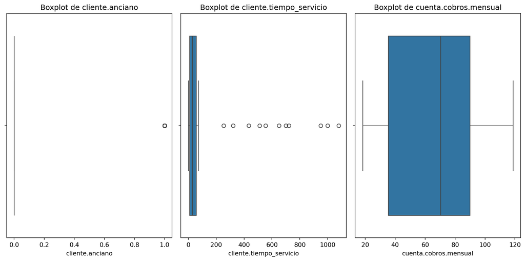

```python
# Configurar el tamaño de la figura
plt.figure(figsize=(12, 6))

# Crear los subplots
plt.subplot(1, 3, 1)
sns.boxplot(x='cliente.anciano', data=datos_churn)
plt.title('Boxplot de cliente.anciano')

plt.subplot(1, 3, 2)
sns.boxplot(x='cliente.tiempo_servicio', data=datos_churn)
plt.title('Boxplot de cliente.tiempo_servicio')

plt.subplot(1, 3, 3)
sns.boxplot(x='cuenta.cobros.mensual', data=datos_churn)
plt.title('Boxplot de cuenta.cobros.mensual')

# Ajustar el layout para que no se superpongan los gráficos
plt.tight_layout()

# Mostrar el gráfico
plt.show()
```

# 3 Tratamiento de Datos

## 3.1 Preprocesamiento

```python
def preprocesamiento(datos_churn):


  #=====================================================================
                            #Limpieza de outliers
  #=====================================================================
    # Calcular cuartiles e IQR
  primer_cuartil = datos_churn['cliente.tiempo_servicio'].quantile(0.25)
  tercer_cuartil = datos_churn['cliente.tiempo_servicio'].quantile(0.75)
  IQR = tercer_cuartil - primer_cuartil

  # Calcular los límites para considerar los valores atípicos
  limite_inferior = primer_cuartil - 1.5 * IQR
  limite_superior = tercer_cuartil + 1.5 * IQR

  # Filtrar los valores que están dentro de los límites
  datos_churn = datos_churn[datos_churn['cliente.tiempo_servicio'].between(limite_inferior, limite_superior)]
    #=====================================================================
                #Relleno de los valores "" en las columnas con nan
  #=====================================================================

    #Primera columna en los datos churn cambairemos los valores '' por nan para despues eliminarlos.
  datos_churn.loc[:, 'Churn'] = datos_churn['Churn'].replace('', np.nan)

  #Segunda Columna en los datos cuenta.cobros.Total cambairemos los valores '' por nan para despues eliminarlos.
  datos_churn.loc[:, 'cuenta.cobros.Total'] = datos_churn['cuenta.cobros.Total'].replace(' ', np.nan)

   #=====================================================================
                            #Limpieza de duplicados y nulos
  #=====================================================================
  datos_churn=datos_churn.dropna()
  datos_churn=datos_churn.drop_duplicates().reset_index(drop=True)

  datos_churn['cuenta.cobros.Total']=datos_churn['cuenta.cobros.Total'].astype('float')
    ## Nueva variables agregadas
  datos_churn['ratio_gasto_tiempo'] = (datos_churn['cuenta.cobros.Total'] / datos_churn['cliente.tiempo_servicio']).round(2)

  # Calcula el gasto total adicional
  datos_churn['gasto_total_adicional'] = datos_churn['cuenta.cobros.Total'] - (datos_churn['cuenta.cobros.mensual'] * datos_churn['cliente.tiempo_servicio'])
  datos_churn['gasto_adicional'] = datos_churn['gasto_total_adicional'].apply(lambda x: x if x > 0 else 0)
    # Elimina la columna 'gasto_total_adicional' si ya no es necesaria
  datos_churn.drop(columns=['gasto_total_adicional'], inplace=True)
  return datos_churn
```

```python
datos_churn=preprocesamiento(datos_churn)
datos_churn.head()
```

|  | id_cliente | Churn | cliente.genero | cliente.anciano | cliente.pareja | cliente.dependientes | cliente.tiempo_servicio | telefono.servicio_telefono | telefono.varias_lineas | internet.servicio_internet | internet.seguridad_online | internet.backup_online | internet.proteccion_dispositivo | internet.soporte_tecnico | internet.tv_streaming | internet.peliculas_streaming | cuenta.contrato | cuenta.facturacion_electronica | cuenta.metodo_pago | cuenta.cobros.mensual | cuenta.cobros.Total | ratio_gasto_tiempo | gasto_adicional |
| --- | --- | --- | --- | --- | --- | --- | --- | --- | --- | --- | --- | --- | --- | --- | --- | --- | --- | --- | --- | --- | --- | --- | --- |
| 0 | 0003-MKNFE | no | masculino | 0 | no | no | 9.0 | si | si | DSL | no | no | no | no | no | si | mensual | no | cheque | 59.9 | 542.40 | 60.27 | 3.3 |
| 1 | 0004-TLHLJ | si | masculino | 0 | no | no | 4.0 | si | no | fibra optica | no | no | si | no | no | no | mensual | si | cheque electronico | 73.9 | 280.85 | 70.21 | 0.0 |
| 2 | 0011-IGKFF | si | masculino | 1 | si | no | 13.0 | si | no | fibra optica | no | si | si | no | si | si | mensual | si | cheque electronico | 98.0 | 1237.85 | 95.22 | 0.0 |
| 3 | 0013-EXCHZ | si | femenino | 1 | si | no | 3.0 | si | no | fibra optica | no | no | no | si | si | no | mensual | si | cheque | 83.9 | 267.40 | 89.13 | 15.7 |
| 4 | 0013-MHZWF | no | femenino | 0 | no | si | 9.0 | si | no | DSL | no | no | no | si | si | si | mensual | si | tarjeta de credito (automatico) | 69.4 | 571.45 | 63.49 | 0.0 |

```
<class 'pandas.core.frame.DataFrame'>
RangeIndex: 6977 entries, 0 to 6976
Data columns (total 23 columns):
 #   Column                           Non-Null Count  Dtype
---  ------                           --------------  -----
 0   id_cliente                       6977 non-null   object
 1   Churn                            6977 non-null   object
 2   cliente.genero                   6977 non-null   object
 3   cliente.anciano                  6977 non-null   int64
 4   cliente.pareja                   6977 non-null   object
 5   cliente.dependientes             6977 non-null   object
 6   cliente.tiempo_servicio          6977 non-null   float64
 7   telefono.servicio_telefono       6977 non-null   object
 8   telefono.varias_lineas           6977 non-null   object
 9   internet.servicio_internet       6977 non-null   object
 10  internet.seguridad_online        6977 non-null   object
 11  internet.backup_online           6977 non-null   object
 12  internet.proteccion_dispositivo  6977 non-null   object
 13  internet.soporte_tecnico         6977 non-null   object
 14  internet.tv_streaming            6977 non-null   object
 15  internet.peliculas_streaming     6977 non-null   object
 16  cuenta.contrato                  6977 non-null   object
 17  cuenta.facturacion_electronica   6977 non-null   object
 18  cuenta.metodo_pago               6977 non-null   object
 19  cuenta.cobros.mensual            6977 non-null   float64
 20  cuenta.cobros.Total              6977 non-null   float64
 21  ratio_gasto_tiempo               6977 non-null   float64
 22  gasto_adicional                  6977 non-null   float64
dtypes: float64(5), int64(1), object(17)
memory usage: 1.2+ MB
```

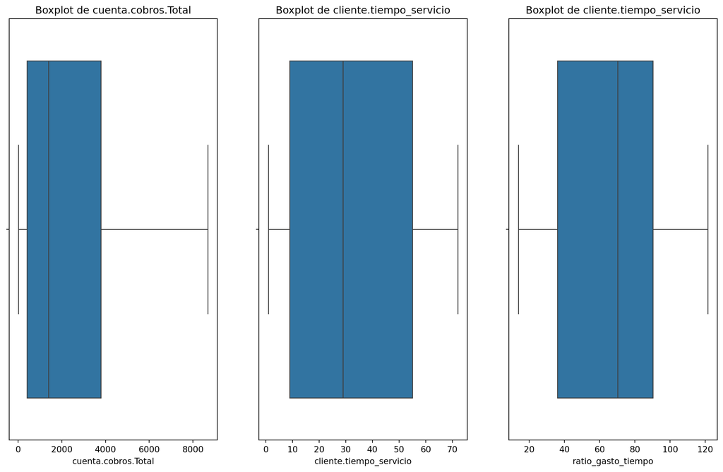

```python
    #=====================================================================
                        #Verificación de los Datos
#=====================================================================
datos_churn.info()
# Configurar el tamaño de la figura
plt.figure(figsize=(15, 9))

# Crear los subplots
plt.subplot(1, 3, 1)
sns.boxplot(x='cuenta.cobros.Total', data=datos_churn)
plt.title('Boxplot de cuenta.cobros.Total')

plt.subplot(1, 3, 2)
sns.boxplot(x='cliente.tiempo_servicio', data=datos_churn)
plt.title('Boxplot de cliente.tiempo_servicio')

plt.subplot(1, 3, 3)
sns.boxplot(x='ratio_gasto_tiempo', data=datos_churn)
plt.title('Boxplot de cliente.tiempo_servicio')
plt.show()
```

## 3.2 Normalización de Datos

```python
#Observamos los valores unicos de cada columna

for col in datos_churn.columns:
    print(f"Columna: {col}")
    print(datos_churn[col].unique())
    print("-" * 30)
```

```
Columna: id_cliente
['0003-MKNFE' '0004-TLHLJ' '0011-IGKFF' ... '9992-UJOEL' '9993-LHIEB'
 '9995-HOTOH']
------------------------------
Columna: Churn
['no' 'si']
------------------------------
Columna: cliente.genero
['masculino' 'femenino']
------------------------------
Columna: cliente.anciano
[0 1]
------------------------------
Columna: cliente.pareja
['no' 'si']
------------------------------
Columna: cliente.dependientes
['no' 'si']
------------------------------
Columna: cliente.tiempo_servicio
[ 9.  4. 13.  3. 71. 63.  7. 54. 72.  5. 56. 34.  1. 45. 50. 23. 55. 26.
 69. 37. 49. 66. 67. 20. 43. 59. 12. 27.  2. 25. 29. 14. 35. 64. 39. 40.
 11.  6. 30. 70. 57. 58. 16. 32. 33. 10. 21. 61. 15. 44. 22. 24. 19. 47.
 62. 46. 52.  8. 60. 48. 28. 41. 53. 68. 31. 36. 17. 18. 65. 51. 38. 42.]
------------------------------
Columna: telefono.servicio_telefono
['si' 'no']
------------------------------
Columna: telefono.varias_lineas
['si' 'no' 'sin servicio de telefono']
------------------------------
Columna: internet.servicio_internet
['DSL' 'fibra optica' 'no']
------------------------------
Columna: internet.seguridad_online
['no' 'si' 'sin servicio de internet']
------------------------------
Columna: internet.backup_online
['no' 'si' 'sin servicio de internet']
------------------------------
```

[output cut: 19 more lines]

```
['cheque' 'cheque electronico' 'tarjeta de credito (automatico)'
 'transferencia bancaria (automatica)']
------------------------------
Columna: cuenta.cobros.mensual
[59.9  73.9  98.   ... 91.75 68.8  67.85]
------------------------------
Columna: cuenta.cobros.Total
[ 542.4   280.85 1237.85 ...  742.9  4627.65 3707.6 ]
------------------------------
Columna: ratio_gasto_tiempo
[60.27 70.21 95.22 ... 46.38 69.07 58.85]
------------------------------
Columna: gasto_adicional
[ 3.3   0.   15.7  ... 33.3  25.95  1.5 ]
------------------------------
```

```python
datos_churn.drop('id_cliente',axis=1,inplace=True)
datos_churn.head()
```

|  | Churn | cliente.genero | cliente.anciano | cliente.pareja | cliente.dependientes | cliente.tiempo_servicio | telefono.servicio_telefono | telefono.varias_lineas | internet.servicio_internet | internet.seguridad_online | internet.backup_online | internet.proteccion_dispositivo | internet.soporte_tecnico | internet.tv_streaming | internet.peliculas_streaming | cuenta.contrato | cuenta.facturacion_electronica | cuenta.metodo_pago | cuenta.cobros.mensual | cuenta.cobros.Total | ratio_gasto_tiempo | gasto_adicional |
| --- | --- | --- | --- | --- | --- | --- | --- | --- | --- | --- | --- | --- | --- | --- | --- | --- | --- | --- | --- | --- | --- | --- |
| 0 | no | masculino | 0 | no | no | 9.0 | si | si | DSL | no | no | no | no | no | si | mensual | no | cheque | 59.9 | 542.40 | 60.27 | 3.3 |
| 1 | si | masculino | 0 | no | no | 4.0 | si | no | fibra optica | no | no | si | no | no | no | mensual | si | cheque electronico | 73.9 | 280.85 | 70.21 | 0.0 |
| 2 | si | masculino | 1 | si | no | 13.0 | si | no | fibra optica | no | si | si | no | si | si | mensual | si | cheque electronico | 98.0 | 1237.85 | 95.22 | 0.0 |
| 3 | si | femenino | 1 | si | no | 3.0 | si | no | fibra optica | no | no | no | si | si | no | mensual | si | cheque | 83.9 | 267.40 | 89.13 | 15.7 |
| 4 | no | femenino | 0 | no | si | 9.0 | si | no | DSL | no | no | no | si | si | si | mensual | si | tarjeta de credito (automatico) | 69.4 | 571.45 | 63.49 | 0.0 |

Eliminamos la columna id ya que esta columna no se la podemos pasar al modelo.

```python
datos_churn['Churn']=datos_churn['Churn'].apply(lambda x: '0' if x == 'no' else '1').astype('int64')
datos_churn.head(1)
```

|  | Churn | cliente.genero | cliente.anciano | cliente.pareja | cliente.dependientes | cliente.tiempo_servicio | telefono.servicio_telefono | telefono.varias_lineas | internet.servicio_internet | internet.seguridad_online | internet.backup_online | internet.proteccion_dispositivo | internet.soporte_tecnico | internet.tv_streaming | internet.peliculas_streaming | cuenta.contrato | cuenta.facturacion_electronica | cuenta.metodo_pago | cuenta.cobros.mensual | cuenta.cobros.Total | ratio_gasto_tiempo | gasto_adicional |
| --- | --- | --- | --- | --- | --- | --- | --- | --- | --- | --- | --- | --- | --- | --- | --- | --- | --- | --- | --- | --- | --- | --- |
| 0 | 0 | masculino | 0 | no | no | 9.0 | si | si | DSL | no | no | no | no | no | si | mensual | no | cheque | 59.9 | 542.4 | 60.27 | 3.3 |

Convertimos nuestra variable CHURN

```python
datos_churn.info()
```

```
<class 'pandas.core.frame.DataFrame'>
RangeIndex: 6977 entries, 0 to 6976
Data columns (total 22 columns):
 #   Column                           Non-Null Count  Dtype
---  ------                           --------------  -----
 0   Churn                            6977 non-null   int64
 1   cliente.genero                   6977 non-null   object
 2   cliente.anciano                  6977 non-null   int64
 3   cliente.pareja                   6977 non-null   object
 4   cliente.dependientes             6977 non-null   object
 5   cliente.tiempo_servicio          6977 non-null   float64
 6   telefono.servicio_telefono       6977 non-null   object
 7   telefono.varias_lineas           6977 non-null   object
 8   internet.servicio_internet       6977 non-null   object
 9   internet.seguridad_online        6977 non-null   object
 10  internet.backup_online           6977 non-null   object
 11  internet.proteccion_dispositivo  6977 non-null   object
 12  internet.soporte_tecnico         6977 non-null   object
 13  internet.tv_streaming            6977 non-null   object
 14  internet.peliculas_streaming     6977 non-null   object
 15  cuenta.contrato                  6977 non-null   object
 16  cuenta.facturacion_electronica   6977 non-null   object
 17  cuenta.metodo_pago               6977 non-null   object
 18  cuenta.cobros.mensual            6977 non-null   float64
 19  cuenta.cobros.Total              6977 non-null   float64
 20  ratio_gasto_tiempo               6977 non-null   float64
 21  gasto_adicional                  6977 non-null   float64
dtypes: float64(5), int64(2), object(15)
memory usage: 1.2+ MB
```

### 3.2.2 División de los Datos

```python
features = datos_churn.drop('Churn', axis=1) #x
target = datos_churn['Churn'] #y
X_train, X_test, y_train, y_test = train_test_split(features, target, test_size=0.20, random_state=12345)
```

```python
X_test.head()
```

|  | cliente.genero | cliente.anciano | cliente.pareja | cliente.dependientes | cliente.tiempo_servicio | telefono.servicio_telefono | telefono.varias_lineas | internet.servicio_internet | internet.seguridad_online | internet.backup_online | internet.proteccion_dispositivo | internet.soporte_tecnico | internet.tv_streaming | internet.peliculas_streaming | cuenta.contrato | cuenta.facturacion_electronica | cuenta.metodo_pago | cuenta.cobros.mensual | cuenta.cobros.Total | ratio_gasto_tiempo | gasto_adicional |
| --- | --- | --- | --- | --- | --- | --- | --- | --- | --- | --- | --- | --- | --- | --- | --- | --- | --- | --- | --- | --- | --- |
| 5598 | masculino | 0 | no | no | 47.0 | si | si | fibra optica | no | si | si | no | si | si | un año | si | cheque electronico | 103.10 | 4889.30 | 104.03 | 43.6 |
| 5942 | femenino | 0 | si | no | 57.0 | si | si | fibra optica | si | no | no | no | si | si | mensual | si | cheque electronico | 99.65 | 5497.05 | 96.44 | 0.0 |
| 2149 | femenino | 0 | si | no | 68.0 | si | si | no | sin servicio de internet | sin servicio de internet | sin servicio de internet | sin servicio de internet | sin servicio de internet | sin servicio de internet | dos años | no | tarjeta de credito (automatico) | 25.80 | 1911.50 | 28.11 | 157.1 |
| 4505 | femenino | 0 | no | no | 6.0 | si | si | fibra optica | si | no | no | no | no | no | mensual | si | cheque electronico | 79.05 | 434.50 | 72.42 | 0.0 |
| 28 | masculino | 0 | si | si | 37.0 | si | no | fibra optica | no | no | no | no | si | si | un año | no | tarjeta de credito (automatico) | 91.20 | 3247.55 | 87.77 | 0.0 |

### 3.2.3 Transformación de Variables

```python
columns_object=datos_churn.select_dtypes(include='object').columns
enc = OrdinalEncoder()
X_train[columns_object] = enc.fit_transform(X_train[columns_object]).astype('int64')
X_test[columns_object] = enc.transform(X_test[columns_object]).astype('int64')
X_test.head()
```

|  | cliente.genero | cliente.anciano | cliente.pareja | cliente.dependientes | cliente.tiempo_servicio | telefono.servicio_telefono | telefono.varias_lineas | internet.servicio_internet | internet.seguridad_online | internet.backup_online | internet.proteccion_dispositivo | internet.soporte_tecnico | internet.tv_streaming | internet.peliculas_streaming | cuenta.contrato | cuenta.facturacion_electronica | cuenta.metodo_pago | cuenta.cobros.mensual | cuenta.cobros.Total | ratio_gasto_tiempo | gasto_adicional |
| --- | --- | --- | --- | --- | --- | --- | --- | --- | --- | --- | --- | --- | --- | --- | --- | --- | --- | --- | --- | --- | --- |
| 5598 | 1 | 0 | 0 | 0 | 47.0 | 1 | 1 | 1 | 0 | 1 | 1 | 0 | 1 | 1 | 2 | 1 | 1 | 103.10 | 4889.30 | 104.03 | 43.6 |
| 5942 | 0 | 0 | 1 | 0 | 57.0 | 1 | 1 | 1 | 1 | 0 | 0 | 0 | 1 | 1 | 1 | 1 | 1 | 99.65 | 5497.05 | 96.44 | 0.0 |
| 2149 | 0 | 0 | 1 | 0 | 68.0 | 1 | 1 | 2 | 2 | 2 | 2 | 2 | 2 | 2 | 0 | 0 | 2 | 25.80 | 1911.50 | 28.11 | 157.1 |
| 4505 | 0 | 0 | 0 | 0 | 6.0 | 1 | 1 | 1 | 1 | 0 | 0 | 0 | 0 | 0 | 1 | 1 | 1 | 79.05 | 434.50 | 72.42 | 0.0 |
| 28 | 1 | 0 | 1 | 1 | 37.0 | 1 | 0 | 1 | 0 | 0 | 0 | 0 | 1 | 1 | 2 | 0 | 2 | 91.20 | 3247.55 | 87.77 | 0.0 |

### 3.2.3 Balanceo de Clases

```python
os_us = RandomOverSampler()
X_train_res, y_train_res = os_us.fit_resample(X_train, y_train)
resultado=pd.concat([X_train_res, y_train_res], axis=1)
resultado['Churn'].value_counts()
```

```
Churn
0    4110
1    4110
Name: count, dtype: int64
```

### 3.2.5 Escalamiento de los Datos

```python
columns=['cliente.tiempo_servicio','cuenta.cobros.mensual','cuenta.cobros.Total','ratio_gasto_tiempo', 'gasto_adicional']

min_max = MinMaxScaler()
X_train[columns] = min_max.fit_transform(X_train[columns])
X_test[columns] = min_max.transform(X_test[columns])
X_test.head()
```

|  | cliente.genero | cliente.anciano | cliente.pareja | cliente.dependientes | cliente.tiempo_servicio | telefono.servicio_telefono | telefono.varias_lineas | internet.servicio_internet | internet.seguridad_online | internet.backup_online | internet.proteccion_dispositivo | internet.soporte_tecnico | internet.tv_streaming | internet.peliculas_streaming | cuenta.contrato | cuenta.facturacion_electronica | cuenta.metodo_pago | cuenta.cobros.mensual | cuenta.cobros.Total | ratio_gasto_tiempo | gasto_adicional |
| --- | --- | --- | --- | --- | --- | --- | --- | --- | --- | --- | --- | --- | --- | --- | --- | --- | --- | --- | --- | --- | --- |
| 5598 | 1 | 0 | 0 | 0 | 0.647887 | 1 | 1 | 1 | 0 | 1 | 1 | 0 | 1 | 1 | 2 | 1 | 1 | 0.844279 | 0.562024 | 0.838524 | 0.118623 |
| 5942 | 0 | 0 | 1 | 0 | 0.788732 | 1 | 1 | 1 | 1 | 0 | 0 | 0 | 1 | 1 | 1 | 1 | 1 | 0.809950 | 0.632154 | 0.767965 | 0.000000 |
| 2149 | 0 | 0 | 1 | 0 | 0.943662 | 1 | 1 | 2 | 2 | 2 | 2 | 2 | 2 | 2 | 0 | 0 | 2 | 0.075124 | 0.218405 | 0.132751 | 0.427425 |
| 4505 | 0 | 0 | 0 | 0 | 0.070423 | 1 | 1 | 1 | 1 | 0 | 0 | 0 | 0 | 0 | 1 | 1 | 1 | 0.604975 | 0.047969 | 0.544669 | 0.000000 |
| 28 | 1 | 0 | 1 | 1 | 0.507042 | 1 | 0 | 1 | 0 | 0 | 0 | 0 | 1 | 1 | 2 | 0 | 2 | 0.725871 | 0.372577 | 0.687366 | 0.000000 |

```python
X_train.info()
```

```
<class 'pandas.core.frame.DataFrame'>
Index: 5581 entries, 4619 to 4578
Data columns (total 21 columns):
 #   Column                           Non-Null Count  Dtype
---  ------                           --------------  -----
 0   cliente.genero                   5581 non-null   int64
 1   cliente.anciano                  5581 non-null   int64
 2   cliente.pareja                   5581 non-null   int64
 3   cliente.dependientes             5581 non-null   int64
 4   cliente.tiempo_servicio          5581 non-null   float64
 5   telefono.servicio_telefono       5581 non-null   int64
 6   telefono.varias_lineas           5581 non-null   int64
 7   internet.servicio_internet       5581 non-null   int64
 8   internet.seguridad_online        5581 non-null   int64
 9   internet.backup_online           5581 non-null   int64
 10  internet.proteccion_dispositivo  5581 non-null   int64
 11  internet.soporte_tecnico         5581 non-null   int64
 12  internet.tv_streaming            5581 non-null   int64
 13  internet.peliculas_streaming     5581 non-null   int64
 14  cuenta.contrato                  5581 non-null   int64
 15  cuenta.facturacion_electronica   5581 non-null   int64
 16  cuenta.metodo_pago               5581 non-null   int64
 17  cuenta.cobros.mensual            5581 non-null   float64
 18  cuenta.cobros.Total              5581 non-null   float64
 19  ratio_gasto_tiempo               5581 non-null   float64
 20  gasto_adicional                  5581 non-null   float64
dtypes: float64(5), int64(16)
memory usage: 959.2 KB
```

## 3.3 Creación del Modelo Random Forest

```python
def pronosticar(train_x, train_y):
  model = RandomForestClassifier(random_state=50)
  model.fit(train_x, train_y)
  return model
```

```python
model = pronosticar(X_train, y_train)
model.score(X_test, y_test)
```

```
0.7951289398280802
```

# 4. Reducción de Dimensionalidad

## 4.1 Métodos Gráficos

```python
columns_object=datos_churn.select_dtypes(include='object').columns
enc = OrdinalEncoder()
datos_churn[columns_object] = enc.fit_transform(datos_churn[columns_object]).astype('int64')
datos_churn.info()
```

```
<class 'pandas.core.frame.DataFrame'>
RangeIndex: 6977 entries, 0 to 6976
Data columns (total 22 columns):
 #   Column                           Non-Null Count  Dtype
---  ------                           --------------  -----
 0   Churn                            6977 non-null   int64
 1   cliente.genero                   6977 non-null   int64
 2   cliente.anciano                  6977 non-null   int64
 3   cliente.pareja                   6977 non-null   int64
 4   cliente.dependientes             6977 non-null   int64
 5   cliente.tiempo_servicio          6977 non-null   float64
 6   telefono.servicio_telefono       6977 non-null   int64
 7   telefono.varias_lineas           6977 non-null   int64
 8   internet.servicio_internet       6977 non-null   int64
 9   internet.seguridad_online        6977 non-null   int64
 10  internet.backup_online           6977 non-null   int64
 11  internet.proteccion_dispositivo  6977 non-null   int64
 12  internet.soporte_tecnico         6977 non-null   int64
 13  internet.tv_streaming            6977 non-null   int64
 14  internet.peliculas_streaming     6977 non-null   int64
 15  cuenta.contrato                  6977 non-null   int64
 16  cuenta.facturacion_electronica   6977 non-null   int64
 17  cuenta.metodo_pago               6977 non-null   int64
 18  cuenta.cobros.mensual            6977 non-null   float64
 19  cuenta.cobros.Total              6977 non-null   float64
 20  ratio_gasto_tiempo               6977 non-null   float64
 21  gasto_adicional                  6977 non-null   float64
dtypes: float64(5), int64(17)
memory usage: 1.2 MB
```

### 4.1.1 Reducción Gráfico de Líneas

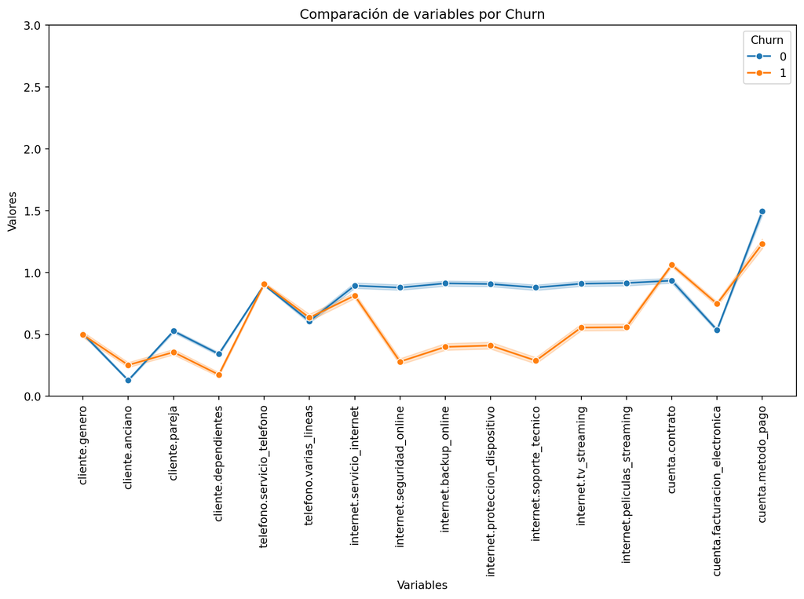

```python
df_int=datos_churn[datos_churn.select_dtypes(include='int').columns]

df_melted = df_int.melt(id_vars='Churn', var_name='Variables', value_name='Valores')

# Grafico con Seaborn
plt.figure(figsize=(12, 6))
sns.lineplot(data=df_melted, x='Variables', y='Valores', hue='Churn', marker='o')

plt.xticks(rotation=90)  # Rotar etiquetas del eje x
plt.ylim(df_melted['Valores'].min(), df_melted['Valores'].max())
plt.title('Comparación de variables por Churn')
plt.show()
```

```python
train_x = X_train.drop(columns=["telefono.varias_lineas",'internet.servicio_internet'])
test_x = X_test.drop(columns=["telefono.varias_lineas",'internet.servicio_internet'])
model = pronosticar(train_x, y_train)
model.score(test_x, y_test)
```

```
0.8058739255014327
```

### 4.1.2 Reducción Gráficos Variables continuas

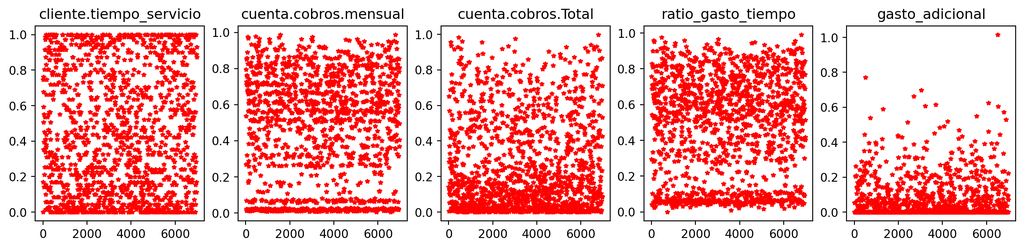

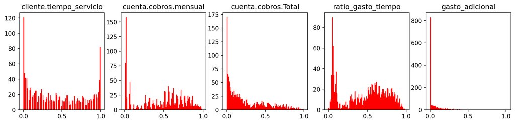

```python
min_max_gra=X_test.loc[:,['cliente.tiempo_servicio','cuenta.cobros.mensual','cuenta.cobros.Total','ratio_gasto_tiempo', 'gasto_adicional']]

fig=plt.figure(figsize=(15,3))
ax1=fig.add_subplot(1,5,1)
ax2=fig.add_subplot(1,5,2)
ax3=fig.add_subplot(1,5,3)
ax4=fig.add_subplot(1,5,4)
ax5=fig.add_subplot(1,5,5)

ax1.set_title("cliente.tiempo_servicio")
ax1.plot(min_max_gra['cliente.tiempo_servicio'],linewidth=0,marker='*',color='red',markersize=4)


ax2.set_title("cuenta.cobros.mensual")
ax2.plot(min_max_gra['cuenta.cobros.mensual'],linewidth=0,marker='*',color='red',markersize=4)

ax3.set_title("cuenta.cobros.Total")
ax3.plot(min_max_gra['cuenta.cobros.Total'],linewidth=0,marker='*',color='red',markersize=4)

ax4.set_title("ratio_gasto_tiempo")
ax4.plot(min_max_gra['ratio_gasto_tiempo'],linewidth=0,marker='*',color='red',markersize=4)

ax5.set_title("gasto_adicional")
ax5.plot(min_max_gra['gasto_adicional'],linewidth=0,marker='*',color='red',markersize=4)

plt.show()



fig=plt.figure(figsize=(15,3))
ax1=fig.add_subplot(1,5,1)
ax2=fig.add_subplot(1,5,2)
ax3=fig.add_subplot(1,5,3)
ax4=fig.add_subplot(1,5,4)
ax5=fig.add_subplot(1,5,5)

ax1.set_title("cliente.tiempo_servicio")
ax1.hist(min_max_gra['cliente.tiempo_servicio'],color='red',bins=100)


ax2.set_title("cuenta.cobros.mensual")
ax2.hist(min_max_gra['cuenta.cobros.mensual'],color='red',bins=100)

ax3.set_title("cuenta.cobros.Total")
ax3.hist(min_max_gra['cuenta.cobros.Total'],color='red',bins=100)

ax4.set_title("ratio_gasto_tiempo")
ax4.hist(min_max_gra['ratio_gasto_tiempo'],color='red',bins=100)

ax5.set_title("gasto_adicional")
ax5.hist(min_max_gra['gasto_adicional'],color='red',bins=100)

plt.show()
```

```python
train_x = X_train.drop(columns=['cuenta.cobros.Total','gasto_adicional'])
test_x = X_test.drop(columns=['cuenta.cobros.Total','gasto_adicional'])
model = pronosticar(train_x, y_train)
model.score(test_x, y_test)
```

```
0.8087392550143266
```

### 4.1.3 Reducción Mapa de Calor

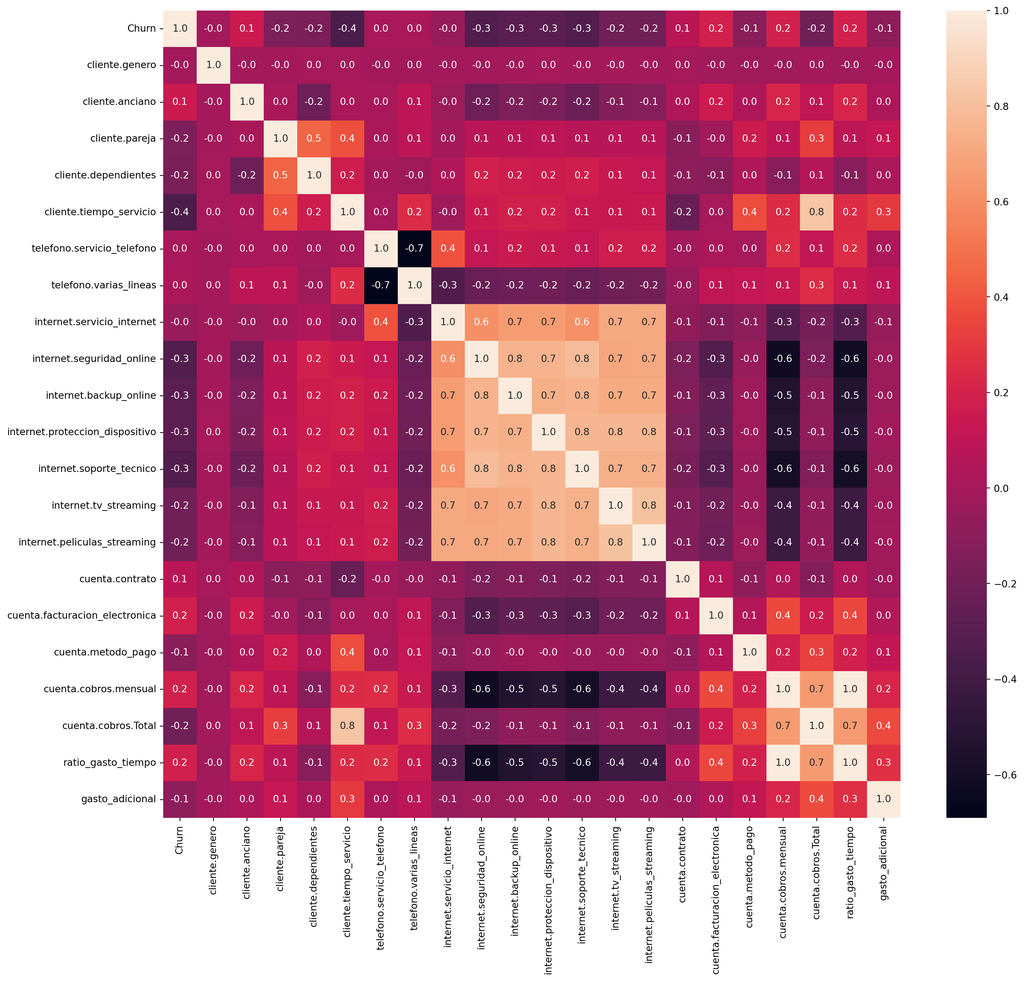

```python
def mapa_calor(df):
    grafico = df.corr()
    plt.figure( figsize = (17,15))
    sns.heatmap(grafico, annot = True, fmt = ".1f")
    return grafico

matriz = mapa_calor(datos_churn)
```

```python
matriz2 = matriz>0.80
matriz2 = matriz2.sum()
matriz2[matriz2>1]
```

```
cliente.tiempo_servicio         2
internet.tv_streaming           2
internet.peliculas_streaming    2
cuenta.cobros.mensual           2
cuenta.cobros.Total             2
ratio_gasto_tiempo              2
dtype: int64
```

```python
train_x = X_train.drop(columns=["internet.tv_streaming",'internet.peliculas_streaming'])
test_x = X_test.drop(columns=["internet.tv_streaming",'internet.peliculas_streaming'])
model = pronosticar(train_x, y_train)
model.score(test_x, y_test)
```

```
0.8008595988538681
```

# 5. Features Importances

Implementamos métodos de selección de características usando SelectKBest, RFE y PCA para reducir la dimensionalidad del conjunto de datos.

## 5.1 SelectKbest

Este método selecciona las mejores características según su relevancia estadística usando la prueba chi-cuadrado. Es útil cuando se trabaja con datos categóricos y selecciona las características más relevantes para el modelo.

```python
def pronosticar_kbest(train_x, test_x, train_y, test_y):
    start_time = time.time()

    train_x = np.abs(train_x)
    test_x = np.abs(test_x)

    selector = SelectKBest(score_func=chi2, k=18)
    train_x_selected = selector.fit_transform(train_x, train_y)
    test_x_selected = selector.transform(test_x)

    model = RandomForestClassifier(random_state=1234)
    model.fit(train_x_selected, train_y)
    test_score = model.score(test_x_selected, test_y)

    print(f"Accuracy en prueba con SelectKBest y chi2: {test_score}")
    end_time = time.time()
    print(f"Tiempo de ejecución: {end_time - start_time:.4f} segundos")

pronosticar_kbest(X_train, X_test, y_train, y_test)
```

```
Accuracy en prueba con SelectKBest y chi2: 0.8044412607449857
Tiempo de ejecución: 0.7632 segundos
```

## 5.2 RFE (Recursive Feature Elimination)

Este algoritmo selecciona características eliminando recursivamente las menos importantes según el modelo. Usa un clasificador (en este caso, RandomForest) para identificar y eliminar las características menos relevantes, dejando solo las más útiles.

```python
def pronosticar_RFE(train_x, test_x, train_y, test_y):
    start_time = time.time()
    model = RandomForestClassifier(random_state=50)
    mejor_n = 0
    mejor_score = 0
    mejores_columnas = []

    for n in range(1, train_x.shape[1] + 1):
        rfe = RFE(estimator=model, n_features_to_select=n)
        rfe.fit(train_x, train_y)
        train_x_rfe = rfe.transform(train_x)

        # Calcular el score con validación cruzada
        scores = cross_val_score(model, train_x_rfe, train_y, cv=5, scoring='accuracy')
        score = scores.mean()

        if score > mejor_score:
            mejor_n = n
            mejor_score = score
            mejores_columnas = list(train_x.columns[rfe.support_])

    # Imprimir resultados
    print(f"Mejor número de características: {mejor_n}")
    print(f"Mejor accuracy: {mejor_score:.4f}")
    print("Mejores columnas seleccionadas:", mejores_columnas)

    # Entrenar el modelo final con las mejores características
    mejor_model = RandomForestClassifier(random_state=50)
    mejor_model.fit(train_x[mejores_columnas], train_y)

    # Evaluar en el conjunto de prueba
    test_x_rfe = test_x[mejores_columnas]
    test_accuracy = mejor_model.score(test_x_rfe, test_y)
    print(f"Accuracy en el conjunto de prueba: {test_accuracy:.4f}")
       # Calcular tiempo de ejecución
    end_time = time.time()
    print(f"Tiempo de ejecución: {end_time - start_time:.4f} segundos")

pronosticar_RFE(X_train, X_test, y_train, y_test)
```

[output not shown]

## 5.3 PCA (Principal Component Analysis):

Este método transforma las características originales en un conjunto de nuevas variables no correlacionadas llamadas componentes principales, que capturan la mayor parte de la variabilidad de los datos, reduciendo la dimensionalidad sin perder mucha información.

```
Utilizando PCA:
El número de características seleccionadas es 12 con un score de 77.58%
Total de varianza explicada por el PCA: 93.10%
Cargas de los Componentes:
                                   PC1    PC2    PC3    PC4    PC5    PC6  \
cliente.genero                   0.001 -0.011  0.007  0.031 -0.010  0.030
cliente.anciano                 -0.069  0.016 -0.021  0.005 -0.134 -0.025
cliente.pareja                   0.035  0.133  0.138 -0.027 -0.042  0.399
cliente.dependientes             0.081  0.048  0.109 -0.019  0.092  0.311
cliente.tiempo_servicio          0.048  0.172  0.118 -0.009 -0.058  0.101
telefono.servicio_telefono       0.064 -0.003 -0.177 -0.145 -0.034  0.067
telefono.varias_lineas          -0.197  0.128  0.464  0.332 -0.160 -0.108
internet.servicio_internet       0.585 -0.026 -0.204 -0.066 -0.244 -0.024
internet.seguridad_online        0.696  0.022  0.056  0.032  0.197  0.001
internet.backup_online           0.674  0.038  0.028  0.040  0.037  0.011
internet.proteccion_dispositivo  0.688  0.048  0.044  0.048 -0.018  0.005
internet.soporte_tecnico         0.705  0.024  0.067  0.023  0.143 -0.029
internet.tv_streaming            0.668  0.028 -0.006  0.040 -0.175  0.001
internet.peliculas_streaming     0.665  0.035 -0.008  0.047 -0.171 -0.017
cuenta.contrato                 -0.118 -0.119 -0.384  0.501  0.033  0.141
cuenta.facturacion_electronica  -0.151  0.027 -0.049 -0.017 -0.265  0.017
cuenta.metodo_pago              -0.090  1.050 -0.153  0.021  0.064 -0.068
cuenta.cobros.mensual           -0.175  0.059 -0.035 -0.053 -0.143  0.064
cuenta.cobros.Total             -0.039  0.114  0.055 -0.017 -0.090  0.084
ratio_gasto_tiempo              -0.163  0.055 -0.032 -0.049 -0.133  0.059
gasto_adicional                 -0.005  0.018  0.008  0.002 -0.014  0.015

                                   PC7    PC8    PC9   PC10   PC11   PC12
cliente.genero                  -0.497  0.002 -0.018 -0.002  0.006  0.009
cliente.anciano                 -0.005 -0.026  0.107  0.050  0.107  0.019
cliente.pareja                   0.021  0.006  0.054 -0.017  0.061  0.008
cliente.dependientes             0.011  0.030 -0.050 -0.179 -0.044 -0.045
cliente.tiempo_servicio          0.001 -0.034  0.015  0.177 -0.010  0.049
telefono.servicio_telefono      -0.003 -0.007  0.018  0.062  0.004  0.027
telefono.varias_lineas           0.010 -0.004  0.061 -0.059  0.027  0.018
internet.servicio_internet      -0.010 -0.005  0.178 -0.166  0.099  0.010
internet.seguridad_online        0.009 -0.098 -0.002  0.012  0.196  0.165
internet.backup_online          -0.013 -0.245  0.172  0.025 -0.208 -0.052
internet.proteccion_dispositivo -0.003  0.065 -0.031  0.125  0.120 -0.287
internet.soporte_tecnico         0.004 -0.036 -0.138  0.034 -0.012  0.059
internet.tv_streaming            0.006  0.132 -0.084 -0.032 -0.110  0.057
internet.peliculas_streaming     0.014  0.134 -0.087  0.008 -0.058  0.070
cuenta.contrato                  0.023 -0.007 -0.005  0.039  0.002  0.012
cuenta.facturacion_electronica   0.015 -0.277 -0.243 -0.057  0.047 -0.037
cuenta.metodo_pago              -0.009  0.011 -0.006 -0.044 -0.001 -0.010
cuenta.cobros.mensual            0.003  0.018  0.014  0.092 -0.014  0.042
cuenta.cobros.Total              0.002 -0.015  0.012  0.151 -0.015  0.046
ratio_gasto_tiempo               0.003  0.017  0.013  0.087 -0.013  0.040
gasto_adicional                  0.002 -0.001 -0.001  0.028  0.001  0.011
```

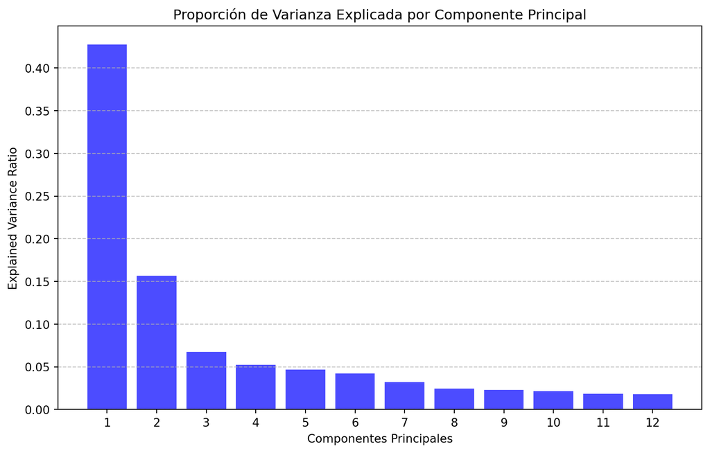

```python
def pronosticar_PCA(train_x, test_x, train_y, test_y,):
    n = 12
    pca = PCA(n_components=n)

    # Ajustar y transformar los datos con PCA
    train_x_pca = pca.fit_transform(train_x)
    model = RandomForestClassifier(random_state=50)
    model.fit(train_x_pca, train_y)
    test_x_pca = pca.transform(test_x)

    # Imprimir resultados de PCA
    print("Utilizando PCA:")
    print(f"El número de características seleccionadas es {n} con un score de {model.score(test_x_pca, test_y) * 100:.2f}%")

    # Calcular y mostrar el total de varianza explicada
    total_varianza_explicada = sum(pca.explained_variance_ratio_)
    print(f"Total de varianza explicada por el PCA: {total_varianza_explicada * 100:.2f}%")

    # Visualizar el explained variance ratio
    plt.figure(figsize=(10, 6))
    plt.bar(range(1, n + 1), pca.explained_variance_ratio_, alpha=0.7, color='blue')
    plt.ylabel('Explained Variance Ratio')
    plt.xlabel('Componentes Principales')
    plt.title('Proporción de Varianza Explicada por Componente Principal')
    plt.xticks(np.arange(1, n + 1, 1))
    plt.grid(axis='y', linestyle='--', alpha=0.7)
    plt.show()

    # Obtener las cargas de los componentes
    loadings = pca.components_.T * np.sqrt(pca.explained_variance_)
    component_names = [f'PC{i+1}' for i in range(n)]
    loadings_df = pd.DataFrame(loadings, index=train_x.columns, columns=component_names)

    # Imprimir las cargas de los componentes
    print("Cargas de los Componentes:")
    print(loadings_df.round(3))

pronosticar_PCA(X_train, X_test, y_train, y_test)
```